# Gold Price Forecasting (India)

Jahnvi Naithani

## 3 Literature Review

Previous studies, such as those by Ghosh & Ghosh and Kale & Patil, have extensively explored gold price behavior in the Indian market using techniques like ARIMA, exponential smoothing models, and classical decomposition. Building upon their work, the present study draws inspiration from these approaches and extends the analysis by employing the R programming environment. In particular, it incorporates multiple trend-fitting techniques, including nonlinear models such as the Gompertz function, to enhance forecasting accuracy and capture complex growth patterns in gold prices.

## 4 Data Description

*The data was sourced from Investing.com, specifically selecting monthly gold prices in INR for a three-year period. The dataset includes the date and closing price of gold futures.*

```r
# Load the dataset
df <- read.csv("gold_prices_2022_2024.csv")

# Convert 'Dates' column to Date format (DD-MM-YYYY)
df$Date <- as.Date(df$Dates, format = "%d-%m-%Y")

# Rename Prices column
df$Price <- df$Prices

# Keep only needed columns
df <- df[, c("Date", "Price")]

# Preview the first few rows
head(df)
```

```
##         Date Price
## 1 2022-01-01 47686
## 2 2022-02-01 50760
## 3 2022-03-01 51585
## 4 2022-04-01 51754
## 5 2022-05-01 50855
## 6 2022-06-01 50517
```

```r
df$Time <- 1:nrow(df)   # Adds 'Time' to your data
Time <- df$Time         # Optional: creates global 'Time' variable
```

## 5 Trend Analysis

*Trend represents the general direction in which a time series moves over a long period. Various methods can be used to identify and model trends:*

### 5.1 Graphical Method

*This method involves plotting the time series data and visually identifying the trend.*

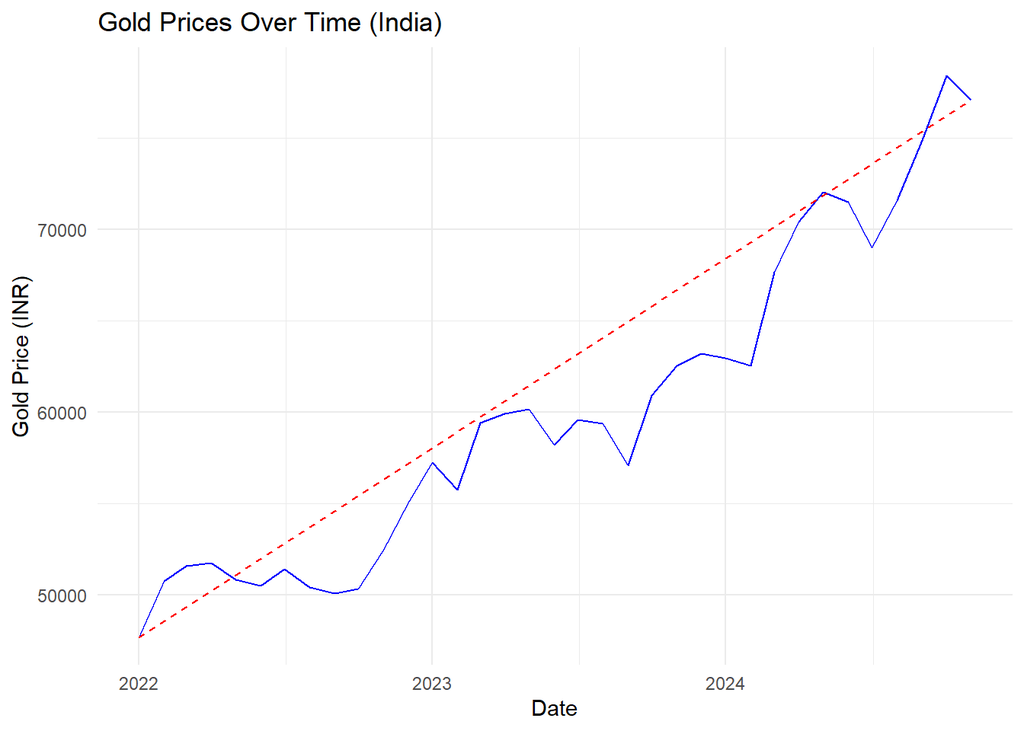

```r
ggplot(df, aes(x = Date, y = Price)) +
  geom_line(color = 'blue') +
  geom_segment(aes(x = min(Date), xend = max(Date),
                   y = Price[1], yend = Price[nrow(df)]),
               color = 'red', linetype = 'dashed') +
  labs(title = 'Gold Prices Over Time (India)',
       x = 'Date', y = 'Gold Price (INR)') +
  theme_minimal()
```

### 5.2 Semi Average Method

*This method divides the data into two equal parts and computes the averages to estimate the trend.*

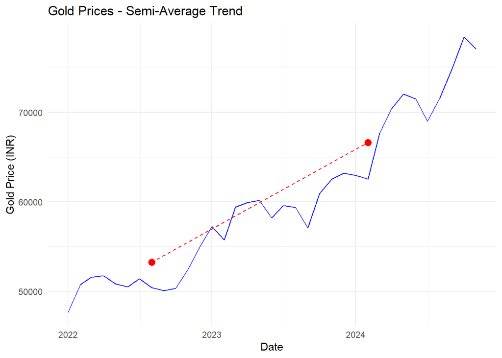

```r
#semiaverage----------------------------------------->>>>>>>>>>>>>>>>>>>>>>>>>>>>>>>>>>>>>>>>>>
# Load necessary libraries
library(ggplot2)

# Split data into two halves
n <- nrow(df)
half <- floor(n / 2)

# Compute averages for each half
first_half_avg <- mean(df$Price[1:half])
second_half_avg <- mean(df$Price[(half+1):n])

# Find middle points of each half
first_half_date <- df$Date[half %/% 2]
second_half_date <- df$Date[half + (n - half) %/% 2]

# Plot actual prices
ggplot(df, aes(x = Date, y = Price)) +
  geom_line(color = "blue") +  # Actual price trend
  geom_point(aes(x = first_half_date, y = first_half_avg), color = "red", size = 3) +  # First half avg
  geom_point(aes(x = second_half_date, y = second_half_avg), color = "red", size = 3) +  # Second half avg
  geom_segment(aes(x = first_half_date, xend = second_half_date,
                   y = first_half_avg, yend = second_half_avg),
               color = "red", linetype = "dashed") +  # Semi-average trend line
  labs(title = "Gold Prices - Semi-Average Trend", x = "Date", y = "Gold Price (INR)") +
  theme_minimal()
```

### 5.3 Least Squares Method

*This method fits a mathematical equation to the time series data.*

#### 5.3.1 Straight Line Equation

$$Y = a + bX$$

```r
#Least Square straight line------------------------------------>>>>>>>>>>>>>>>>>>>>>>>>>>>>>>>>>
# Load required libraries
library(ggplot2)

# Create a month index for regression (1, 2, 3, ..., n)
df$Month_Number <- 1:nrow(df)

# Convert Price column to numeric (remove commas if present)
df$Price <- as.numeric(gsub(",", "", df$Price))

# Perform linear regression (Least Squares Method)
trend_model <- lm(Price ~ Month_Number, data=df)

# Get model coefficients
a <- coef(trend_model)[1]  # Intercept
b <- coef(trend_model)[2]  # Linear term

# Print final equation
cat(sprintf("Trend Equation: Y = %.4f + %.4f*X", a, b))
```

```
## Trend Equation: Y = 45494.8992 + 813.1294*X
```

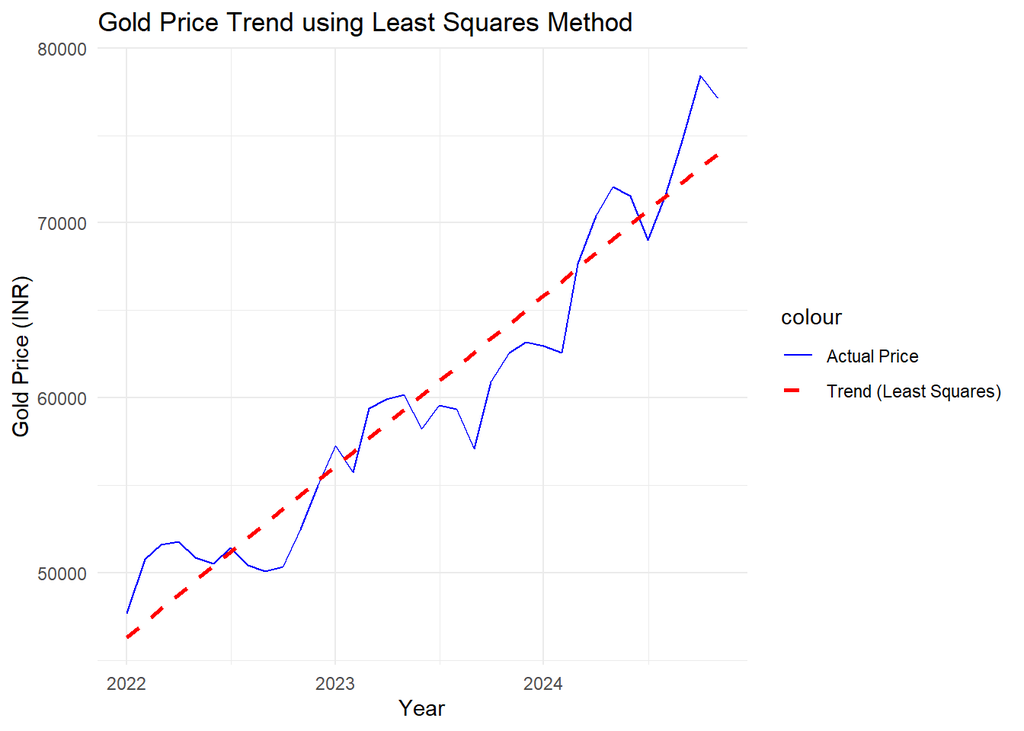

```r
# Add predicted trend values
df$Trend_Least_Squares <- predict(trend_model)

# Plot actual vs. trend
ggplot(df, aes(x=Date)) +
  geom_line(aes(y=Price, color="Actual Price")) +
  geom_line(aes(y=Trend_Least_Squares, color="Trend (Least Squares)"), linetype="dashed", size=1) +
  labs(title="Gold Price Trend using Least Squares Method",
       x="Year", y="Gold Price (INR)") +
  scale_color_manual(values=c("Actual Price"="blue", "Trend (Least Squares)"="red")) +
  theme_minimal()
```

#### 5.3.2 Quadratic (2nd Degree) Equation

$$Y = a + bX + cX^2$$

```r
#Least Square 2nd degree Quadratic------------------------------------------->>>>>>>>>>>>>>>>>>>>>>>>>>>

# Load necessary libraries
library(ggplot2)

# Fit 2nd-degree polynomial model (quadratic trend)
model <- lm(Price ~ poly(Time, 2, raw=TRUE), data=df)

# Get model coefficients
a <- coef(model)[1]  # Intercept
b <- coef(model)[2]  # Linear term
c <- coef(model)[3]  # Quadratic term

# Print final equation
cat(sprintf("Trend Equation: Y = %.4f + %.4f*X + %.4f*X^2\n", a, b, c))
```

```
## Trend Equation: Y = 49425.6555 + 175.7095*X + 17.7061*X^2
```

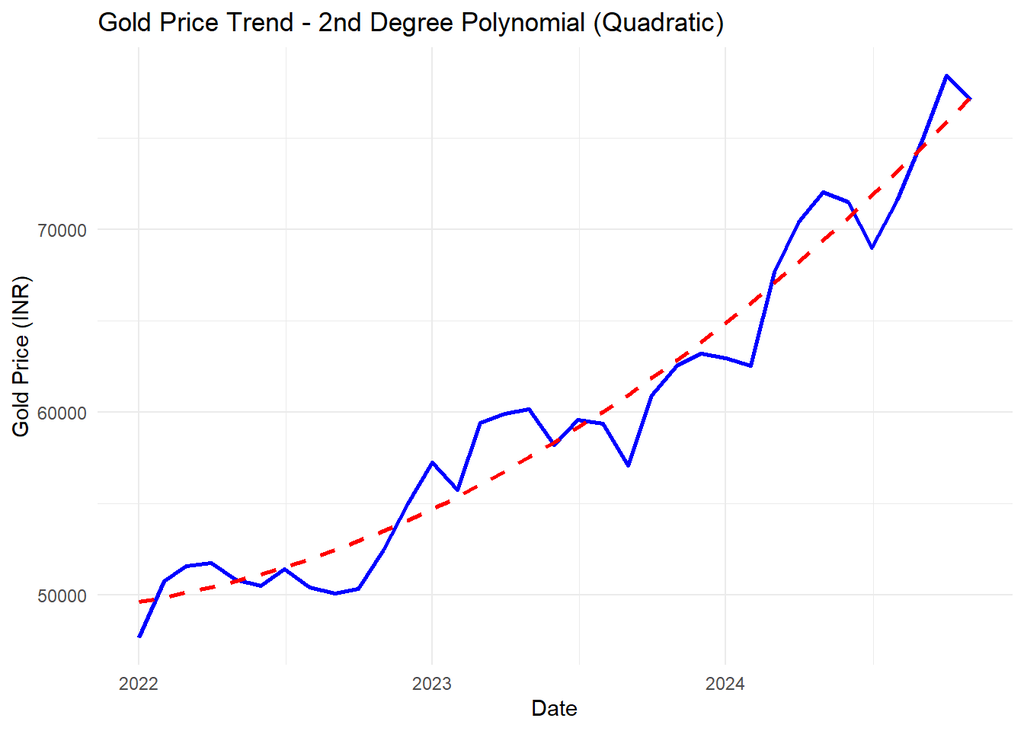

```r
# Predict values
Predicted <- predict(model, newdata=df)

# Plot actual vs predicted prices
ggplot(df, aes(x = Date)) +
  geom_line(aes(y = Price), color = "blue", size = 1, linetype = "solid") +  # Actual prices
  geom_line(aes(y = Predicted), color = "red", size = 1, linetype = "dashed") +  # Quadratic trend
  labs(title = "Gold Price Trend - 2nd Degree Polynomial (Quadratic)",
       x = "Date", y = "Gold Price (INR)") +
  theme_minimal()
```

#### 5.3.3 Exponential Trend

$$Y = ae^{bX}$$

```r
#exponential ----------------------------------------------------------->>>>>>>>>>>>>>>>>>>>>>>>>>

# Load necessary libraries
library(ggplot2)

# Transform price using natural log
LogPrice <- log(df$Price)

# Fit exponential model (linear regression on log-transformed price)
model <- lm(LogPrice ~ Time, data = df)

# Extract coefficients
ln_a <- coef(model)[1]  # ln(a)
b <- coef(model)[2]      # b

# Convert back to original scale
a <- exp(ln_a)  # a = e^(ln_a)

# Print final exponential equation
cat(sprintf("Exponential Trend Equation: Y = %.4f * e^(%.4f * X)\n", a, b))
```

```
## Exponential Trend Equation: Y = 46819.0346 * e^(0.0134 * X)
```

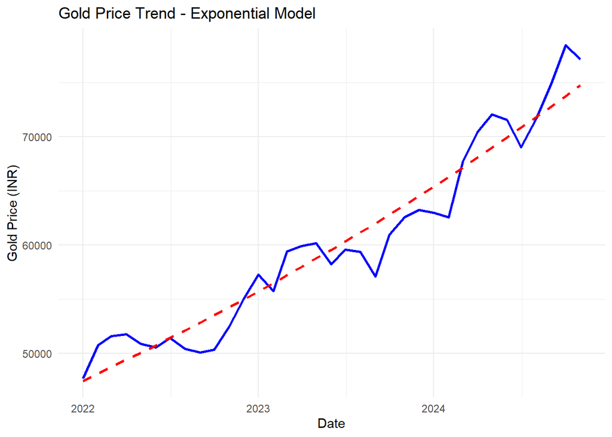

```r
# Predict values & transform back
Predicted <- exp(predict(model, newdata=df))

# Plot actual vs predicted prices
ggplot(df, aes(x = Date)) +
  geom_line(aes(y = Price), color = "blue", size = 1, linetype = "solid") +  # Actual prices
  geom_line(aes(y = Predicted), color = "red", size = 1, linetype = "dashed") +  # Exponential trend
  labs(title = "Gold Price Trend - Exponential Model",
       x = "Date", y = "Gold Price (INR)") +
  theme_minimal()
```

#### 5.3.4 Modified Exponential Trend

$$Y = \frac{1}{a + bX}$$

```r
#modified exp------------------------------------------------------------->>>>>>>>>>>>>>>>>>>>>>>>>>>>
# Load necessary library
library(ggplot2)

# Transform price using reciprocal
InvPrice <- 1 / df$Price

# Fit modified exponential model (linear regression on transformed data)
model <- lm(InvPrice ~ Time, data = df)

# Extract coefficients
a <- coef(model)[1]
b <- coef(model)[2]

# Print final modified exponential equation
cat(sprintf("Modified Exponential Equation: Y = 1 / (%.6f + %.6f * X)\n", a, b))
```

```
## Modified Exponential Equation: Y = 1 / (0.000021 + -0.000000 * X)
```

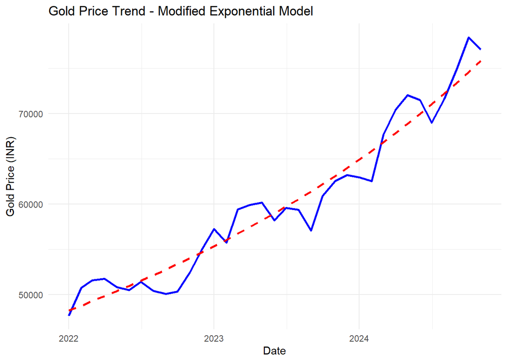

```r
# Predict values & transform back
Predicted <- 1 / predict(model, newdata=df)

# Plot actual vs predicted prices
ggplot(df, aes(x = Date)) +
  geom_line(aes(y = Price), color = "blue", size = 1, linetype = "solid") +  # Actual prices
  geom_line(aes(y = Predicted), color = "red", size = 1, linetype = "dashed") +  # Modified exponential trend
  labs(title = "Gold Price Trend - Modified Exponential Model",
       x = "Date", y = "Gold Price (INR)") +
  theme_minimal()
```

#### 5.3.5 Gompertz Curve

$$Y = a \cdot e^{-b \cdot
e^{-cX}}$$

```r
#gompertz -------------------------------------------------------------------->>>>>>>>>>>>>>>>>>>>>>
# Load necessary libraries
library(minpack.lm)  # For nonlinear regression
library(ggplot2)

# Gompertz function definition
gompertz <- function(Time, a, b, c) {
  return(a * exp(-b * exp(-c * Time)))
}

# Fit nonlinear least squares model
model <- nlsLM(Price ~ gompertz(Time, a, b, c),
               data = df,
               start = list(a = max(df$Price), b = 1, c = 0.1))
# Extract coefficients
coeffs <- coef(model)
a <- coeffs["a"]
b <- coeffs["b"]
c <- coeffs["c"]

# Print final Gompertz equation
cat(sprintf("Gompertz Equation: Y = %.6f * exp(-%.6f * exp(-%.6f * X))\n", a, b, c))
```

```
## Gompertz Equation: Y = 848317.745007 * exp(-2.913466 * exp(-0.005188 * X))
```

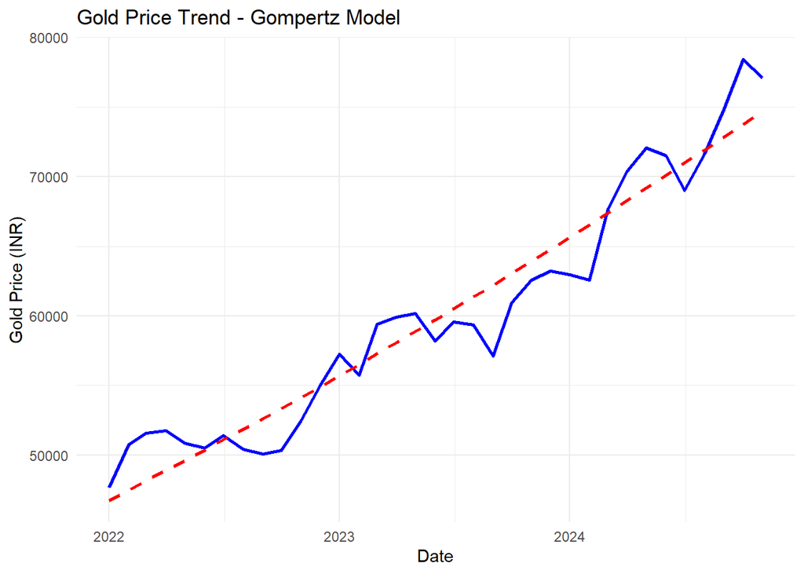

```r
# Predict values
Predicted <- predict(model, newdata = df)

# Plot actual vs predicted values
ggplot(df, aes(x = Date)) +
  geom_line(aes(y = Price), color = "blue", size = 1, linetype = "solid") +  # Actual prices
  geom_line(aes(y = Predicted), color = "red", size = 1, linetype = "dashed") +  # Gompertz curve
  labs(title = "Gold Price Trend - Gompertz Model",
       x = "Date", y = "Gold Price (INR)") +
  theme_minimal()
```

### 5.4 Moving Average Method

*A moving average smooths fluctuations to reveal underlying trends.*

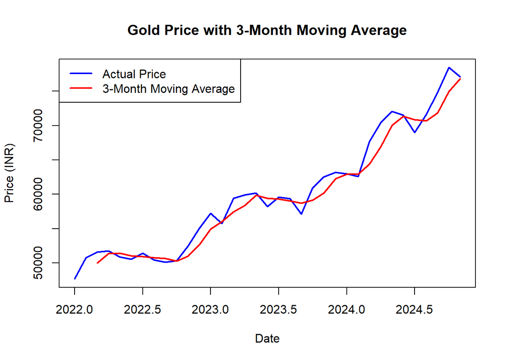

```r
##3 month moving average------------------------------------------>>>>>>>>>>>>>>>>>>
# Load necessary library
library(TTR)

# Convert to time series
ts_gold <- ts(df$Price, start=c(2022,1), frequency=12)

# Compute 3-month moving average
ma_3 <- SMA(ts_gold, n=3)

# Plot original data and moving average
plot(ts_gold, type="l", col="blue", lwd=2, main="Gold Price with 3-Month Moving Average",
     xlab="Date", ylab="Price (INR)")
lines(ma_3, col="red", lwd=2)

# Add legend
legend("topleft", legend=c("Actual Price", "3-Month Moving Average"),
       col=c("blue", "red"), lwd=2)
```

## 6 Seasonal Indicies

*Seasonal variations are periodic fluctuations that repeat over a specific interval.*

### 6.1 Seasonal Indices Ratio to Trend Method

```r
#seasonal Indicies---------------------------*****************************************************

#ratio to trend------------------------------------------------------>>>>>>>>>>>>>>>
# Load required libraries
library(ggplot2)

Month <- format(df$Date, "%m")  # Extract month
Year <- format(df$Date, "%Y")  # Extract year

# Fit a linear trend model (Least Squares Method)
trend_model <- lm(Price ~ Time, data=df)

# Predict trend values
Trend_Value <- predict(trend_model)

# Calculate Ratio to Trend
Ratio_to_Trend <- df$Price / Trend_Value

# Compute Seasonal Indices (Average Ratio for Each Month)
seasonal_indices <- aggregate(Ratio_to_Trend ~ Month, data=df, FUN=mean)
seasonal_indices$Seasonal_Index <- seasonal_indices$Ratio_to_Trend * 100  # Convert to percentage

# Print Seasonal Indices
print(seasonal_indices)
```

```
##    Month Ratio_to_Trend Seasonal_Index
## 1     01      1.0024039      100.24039
## 2     02      0.9988059       99.88059
## 3     03      1.0363928      103.63928
## 4     04      1.0391262      103.91262
## 5     05      1.0278072      102.78072
## 6     06      0.9981220       99.81220
## 7     07      0.9860624       98.60624
## 8     08      0.9774162       97.74162
## 9     09      0.9654311       96.54311
## 10    10      0.9907719       99.07719
## 11    11      0.9937261       99.37261
## 12    12      0.9839714       98.39714
```

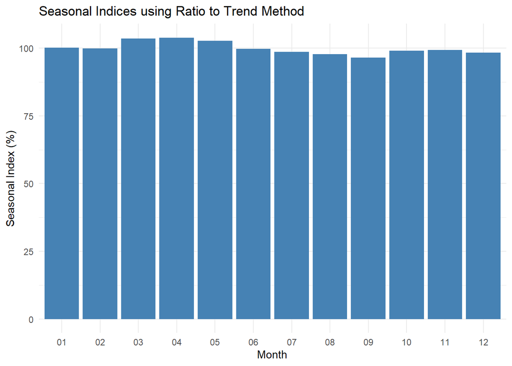

```r
# Plot Seasonal Indices
ggplot(seasonal_indices, aes(x=Month, y=Seasonal_Index)) +
  geom_bar(stat="identity", fill="steelblue") +
  labs(title="Seasonal Indices using Ratio to Trend Method",
       x="Month", y="Seasonal Index (%)") +
  theme_minimal()
```

### 6.2 Seasonal Indices Ratio to Moving Averages Method

```r
#ratio to moving averages------------------------------------------>>>>>>>>>>>>>>>>>>>>>>>>>>>>>>>>>>>>>>>>>
# Load necessary libraries
library(TTR)

# Convert to time series
ts_gold <- ts(df$Price, start = c(2022,1), frequency = 12)

# Calculate 12-month Centered Moving Average (CMA)
cma <- SMA(ts_gold, n = 12)

# Compute Ratio to Moving Average (Actual / CMA)
ratios <- ts_gold / cma

# Convert to dataframe for easy processing
ratio_df <- data.frame(Date = df$Date, Price = ts_gold, CMA = cma, Ratio = ratios)

# Compute seasonal indices (Average Ratio for each month)
Month <- format(ratio_df$Date, "%m")  # Extract month
seasonal_indices <- aggregate(Ratio ~ Month, data = ratio_df, FUN = mean, na.rm = TRUE)

# Normalize to sum to 120 (optional step)
seasonal_indices$Index <- (seasonal_indices$Ratio / sum(seasonal_indices$Ratio)) * 120

# Print seasonal indices
print(seasonal_indices)
```

```
##    Month    Ratio     Index
## 1     01 1.077025  9.930125
## 2     02 1.050262  9.683377
## 3     03 1.114066 10.271650
## 4     04 1.126033 10.381978
## 5     05 1.124361 10.366565
## 6     06 1.086235 10.015047
## 7     07 1.065850  9.827094
## 8     08 1.068549  9.851979
## 9     09 1.055516  9.731816
## 10    10 1.095156 10.097297
## 11    11 1.082071  9.976657
## 12    12 1.070115  9.866416
```

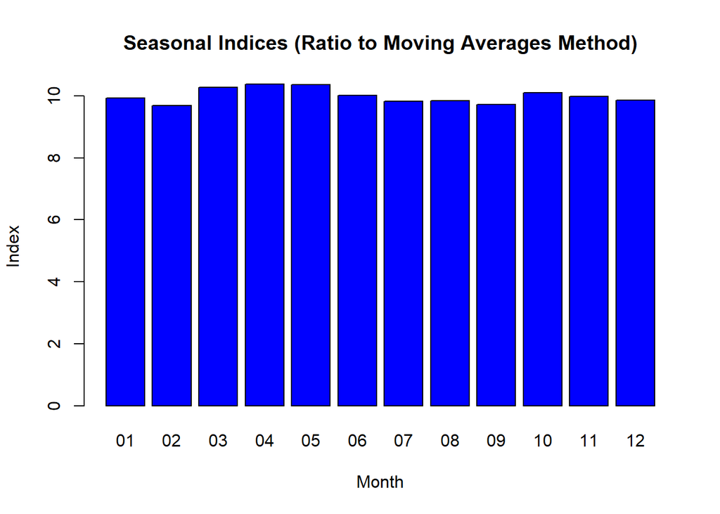

```r
# Plot seasonal indices
barplot(seasonal_indices$Index, names.arg = seasonal_indices$Month, col = "blue",
        main = "Seasonal Indices (Ratio to Moving Averages Method)", xlab = "Month", ylab = "Index")
```

## 7 Prediction 2025

*Using the least squares trend equation of 2nd degree polynomial, :*

```r
#prediction 2025 using Least Square Quadratic------------------------------------>>>>>>>>>>>>>>>>>>>>>>>>>>>>>>>>>

# Load necessary libraries
library(ggplot2)

# Fit a 2nd-degree polynomial model (quadratic trend) to the data
model <- lm(Price ~ poly(Time, 2, raw=TRUE), data=df)

# Predict for the time index corresponding to 2025 (you need to extend the index)
# For example, if you have data from 2022-2024 (35 months), we need time indices for 2025
# Let's say the current time index ends at month 35, so for 2025 we continue with months 36 to 48.

# Extend time indices for 2025
Time_2025 <- 36:48  # The time index for 2025, assuming your data ends at month 36.

# Create the quadratic term for the extended time indices
Time_Squared_2025 <- Time_2025^2

# Create new data for 2025 predictions
new_data_2025 <- data.frame(Time = Time_2025, Time_Squared = Time_Squared_2025)

# Predict gold prices for 2025
Predicted_2025 <- predict(model, newdata = new_data_2025)

# Create a data frame with the predicted results for 2025
predictions_2025 <- data.frame(
  Month = Time_2025 - 35,  # Adjusting the month number to be 1-12 for 2025
  Predicted_Gold_Price = Predicted_2025
)

# Print the predictions for 2025
print(predictions_2025)
```

```
##    Month Predicted_Gold_Price
## 1      1             78698.31
## 2      2             80166.57
## 3      3             81670.24
## 4      4             83209.32
## 5      5             84783.81
## 6      6             86393.71
## 7      7             88039.03
## 8      8             89719.76
## 9      9             91435.90
## 10    10             93187.45
## 11    11             94974.42
## 12    12             96796.80
## 13    13             98654.59
```

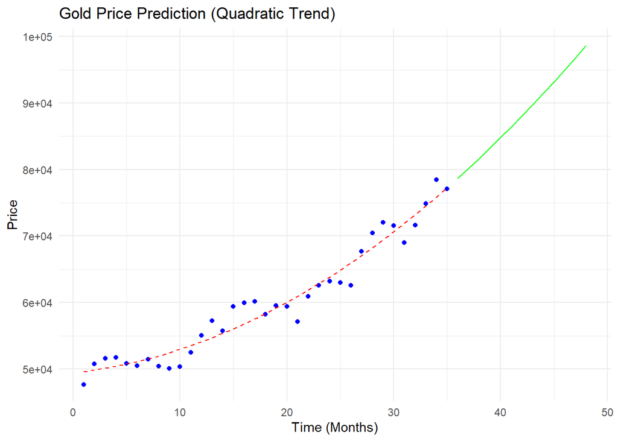

```r
# Optionally, plot the results for 2025 with the previous data
ggplot() +
  geom_point(data = df, aes(x = Time, y = Price), color = 'blue') +  # Original price
  geom_line(data = df, aes(x = Time, y = predict(model, newdata=df)), color = 'red', linetype = "dashed") +  # Predicted price for existing data
  geom_line(data = predictions_2025, aes(x = Month + 35, y = Predicted_Gold_Price), color = 'green', linetype = "solid") +  # Predicted for 2025
  labs(title = "Gold Price Prediction (Quadratic Trend)",
       x = "Time (Months)",
       y = "Price") +
  theme_minimal()
```

## 8 Conclusion

Gold prices in India have demonstrated a steady upward trend from 2022 to 2024, a pattern that reflects the commodity’s role as both a safe-haven asset and a culturally significant investment. Through the application of various time series models — including linear, quadratic, exponential, modified exponential, and the nonlinear Gompertz curve — this study explored the underlying structure of price movements and their future trajectories.

This research serves as a foundation for gold price modeling using classical time series techniques and emphasizes the value of interpretability, especially when dealing with relatively limited but reliable datasets. While the current analysis is based solely on historical prices, future work could integrate external economic variables such as inflation, interest rates, or global market indices. Additionally, incorporating ARIMA models, hybrid statistical-learning techniques, or machine learning approaches (like LSTM or Prophet) could further improve forecast precision and adaptability.

Overall, this study offers valuable insights for investors, financial analysts, and researchers seeking to understand and anticipate gold price movements in the Indian market.

## 9 References

1. Ghosh, S. P., and Ghosh, A. (2017). Forecasting Gold Prices Using ARIMA Model: A Study Based on Indian Market. International Journal of Business and Management Invention, 6(5), 10–19.
2. Kale, P. B., and Patil, P. S. (2021). Forecasting Gold Price Using Various Time Series and Machine Learning Techniques. International Journal of Scientific Research in Science and Technology, 8(5), 118–122.
3. Investing.com. Historical Gold Futures Data. [ https://www.investing.com/commodities/gold-historical-data ]
4. Box, G. E. P., Jenkins, G. M., Reinsel, G. C., and Ljung, G. M. (2015). Time Series Analysis: Forecasting and Control (5th ed.). Wiley.
5. Sharma, R., and Dutta, A. (2020). Seasonal and Trend Analysis of Gold Prices in India: A Time Series Perspective. Journal of Economics and Financial Studies, 8(3), 35–42.
6. Salhi, M. E., and Ariff, A. M. (2019). Nonlinear Time Series Modelling of Gold Prices Using Gompertz Curve. International Conference on Applied Mathematics and Data Science.
7. Patel, R., and Shah, M. (2021). Forecasting Gold Prices Using ARIMA and Exponential Smoothing Models. International Journal of Statistics and Applied Economics, 9(2), 45-52.